# Tutorial: Cheap code and the Multivariate Case

## Implementing the computer model

Similar to the univariate case, the user need to implement his/her own computer model and its derivative in C++ class in the package `calibration`. We illustrate this via the third simulation setting of this work.

In the third simulation setting of this work, the physical response is
$$y^p(x) = 1 + x^3 + \sigma e$$
for $x\in [1, 2]$, where $\sigma=0.2$ and $e \sim N(0,1)$. The computer model is
$$y^s(x, \boldsymbol \theta) = \theta_1 x + \theta_2 x^2$$
with two calibration parameters $\theta_1$ and $\theta_2$.

The computer model of this simulation setting is implemented in the file `calibration/src/simuObj_multivariate.hpp` The class `simuobj_multi1` also inherits from `simuobj`. The user need to override the function `yModel`, `yModelPartial` and `yModelPartial2OCross` from the base class. These functions take `theta` and `dataXReal` as inputs, which are $n\times q$ and $n\times 1$ matrices, respectively. Note the dimension of the multivariate $\boldsymbol \theta$ is $q$. In math notations, the function inputs `theta` and `dataXReal` are
$$\begin{pmatrix}
\theta_1(x_1) & \theta_2(x_1) & \cdots & \theta_q(x_1) \\
\theta_1(x_2) & \theta_2(x_2) & \cdots & \theta_q(x_2) \\
\vdots & \vdots & & \vdots\\
\theta_1(x_n) & \theta_2(x_n) & \cdots & \theta_q(x_n) \\
\end{pmatrix}\quad \text{and} \quad
\begin{pmatrix}
x_1 \\ x_2 \\ \vdots \\ x_n
\end{pmatrix},$$
respectively. The function `yModelPartial` returns a matrix of size $n\times q$ containing the values of $\frac{\partial y^s(x,\boldsymbol \theta)}{\partial \theta_j}$ in its columns for $j=1,\cdots, q$. Lastly, the function returns a vector of size $n\times 1$ containing the value of $\frac{\partial^2 y^s(x,\boldsymbol \theta)}{\partial \theta_i\partial \theta_j}$ for all observation and for a specific $(i,j)$ value.

```cpp
// File: calibration/src/simuObj_multivariate.hpp
// the third simulation setup
class simuobj_multi1:
    public simuobj{
public:
    vec yModel(const mat & theta, const mat & dataXReal){
        vec result;
        result = theta.col(0) % dataXReal;
        result += theta.col(1) % dataXReal % dataXReal;
        return result;
    }

    // The first order partial derivatives
    // Each row for one observation
    // Each column for one theta
    mat yModelPartial(const mat & theta, const mat & dataXReal){
        mat result(dataXReal.n_rows, 2);
        result.col(0) = dataXReal;
        result.col(1) = dataXReal % dataXReal;
        return result;
    }


    vec yModelPartial2OCross(const mat & theta,
                             const mat & dataXReal,
                             int i, int j){
        return arma::zeros<vec>(dataXReal.n_rows);
    }

};
```

The computer model for multivariate calibration problem will be used by the class `calModelMulti` in the file `calibration/src/method_RKHS_multivariate.hpp` and `calibration/src/method_RKHS_multivariate.hpp`.

## Use the computer model

```r
library(calibration)
library(snowfall)
source("./code/core/multi_loadAll.R")
linkLowerB = -20
linkUpperB = 20
nSample = 50
lowerB = 1
upperB = 2
TrueSeqX = seq(lowerB, upperB, length.out = 200)
TrueSeqX = matrix(TrueSeqX, ncol = 1)
TrueSeqY = 1 + TrueSeqX^3
TrueSeqTheta = cbind(1/TrueSeqX, TrueSeqX)
lenLambda = 50
lambdaSeq = rev(exp(seq(-7,3, length.out = lenLambda)))
```

Generate a group of samples of size $n=50$.

```r
y_physics = function(nSample, lowerB, upperB){
    xData = matrix(runif(nSample, lowerB, upperB), ncol = 1)
    yPhysical = 1 + xData^3 + rnorm(nSample, sd = 0.2)
    return(list(x = xData, y = yPhysical))
}
simuData = y_physics(nSample,lowerB, upperB)
```

Create a C++ object. The user need to specify the dimension of $\boldsymbol \theta$. In this example, we set `numComp = 2`, which means $\boldsymbol \theta$ is 2-dimensional.

```r
modelObjCC = create_CalibrationObj(problemIndex = 1,
                                   thetaIndex = 5, linkIndex = 2,
                                   numComp = 2,
                                   linkLowerB = linkLowerB,
                                   linkUpperB = linkUpperB)
modelObjCC$setData(simuData$y, simuData$x, lowerB, upperB)
```

The function `getInit` providing random initial values returns a matrix with two columns. Each column has the initial value for one $\theta_j$.

```r
getInit = function(nSample){
    gamma = matrix(rnorm(2 * (nSample + 2), sd = 5), ncol = 2)
    return(gamma)
}
res = selectLambdaGCV_multi(modelObjCC, lambdaSeq, getInit, nSample)
lambdaOpt = res$lambdaOpt
modelObjCC$setLambda(lambdaOpt)
res = optimize_CalModel_multi(getInit, nSample, modelObjCC, nTry = 50)
optGamma = res$par
```

The matrix `ySeqHat` has three columns. It contains the fitted value of $y$, $\theta_1$ and $\theta_2$ in its columns. The fitted values are computed at $x$ values inside `TrueSeqX`. The one sigma uncertainty of these fitted values are contained in `ySigma`, which is also a matrix with three columns. Let’s plot the observation in black points and the fitted response in red curve.

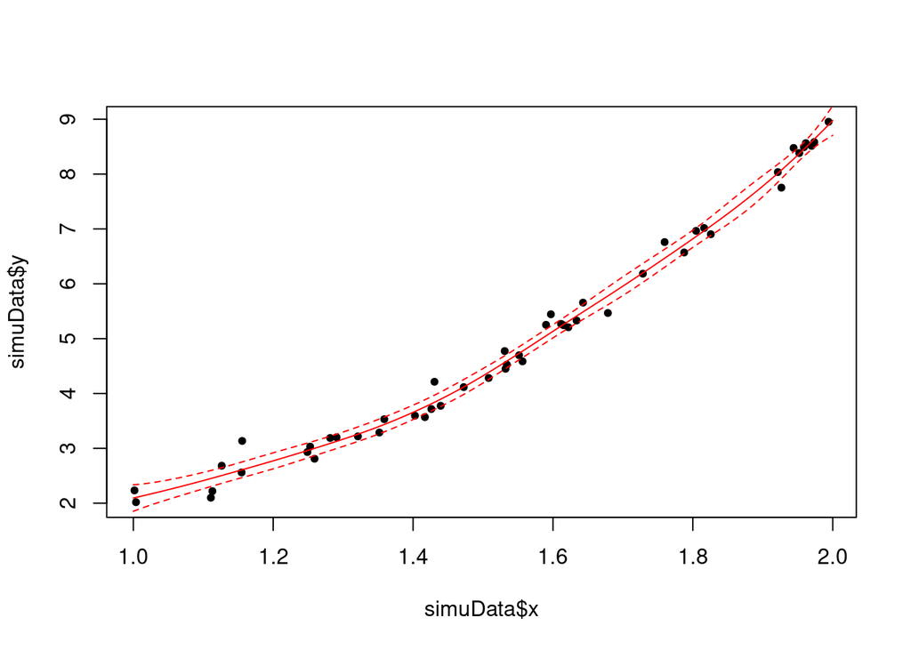

```r
ySeqHat = modelObjCC$predict_y(optGamma, TrueSeqX, FALSE)
ySigma = modelObjCC$sigmaSq_y(optGamma, TrueSeqX,  lambdaOpt)
plot(simuData$x, simuData$y, pch = 20)
lines(TrueSeqX, ySeqHat[,1], col = "red")
lines(TrueSeqX, ySeqHat[,1]+1.96*ySigma[,1], col = "red", lty = 2)
lines(TrueSeqX, ySeqHat[,1]-1.96*ySigma[,1], col = "red", lty = 2)
```

## One more example

In the forth simulation setting, the physical response is $y^p(x) =x^3+ \sigma e$ for $x\in[1, 2]$, where $\sigma=0.2$ and $e \sim N(0,1)$. The computer model is $y^s(x, \boldsymbol \theta) = \theta_1 x^{\theta_2}$ with two calibration parameters $\theta_1$ and $\theta_2$. The implementation of this computer model and its derivatives can also be found in `calibration/src/simuObj_multivariate.hpp`.

```cpp
// the fourth simulation setup
class simuobj_multi2:
    public simuobj{
public:
    vec yModel(const mat & theta, const mat & dataXReal){
        vec result(dataXReal.n_rows);

        size_t i;
        for(i = 0; i < dataXReal.n_rows; i++){
            result(i) = theta(i,0) * pow(dataXReal(i,0), theta(i,1));
        }
        return result;
    }
    mat yModelPartial(const mat & theta, const mat & dataXReal){
        mat result(dataXReal.n_rows, 2);
        size_t i;
        for(i = 0; i < dataXReal.n_rows; i++){
            result(i,0) = pow(dataXReal(i,0), theta(i,1));
            result(i,1) = result(i,0) * theta(i,0) * log(dataXReal(i,0));
        }
        return result;
    }


    vec yModelPartial2OCross(const mat & theta,
                             const mat & dataXReal,
                             int p, int q){
        vec result(dataXReal.n_rows, fill::zeros);
        size_t i;
        if(p==0 && q ==0){
            result = arma::zeros(dataXReal.n_rows, 1);
        }

        if(p==1 && q ==1){
            for(i = 0; i < dataXReal.n_rows; i++){
                result(i) = theta(i,0) * pow(dataXReal(i,0), theta(i,1))
                * std::log(dataXReal(i,0)) * std::log(dataXReal(i,0));
            }
        }

        if(p!=q){
            for(i = 0; i < dataXReal.n_rows; i++){
                result(i) = pow(dataXReal(i,0), theta(i,1)) *
                    std::log(dataXReal(i,0));
            }
        }


        return result;
    }

};
```